# R Notebook

```r
library(prob)
library(tidyverse)
```

## Lesson 1

Distributions - measures of centre

definition - all the possible outcome of a random variable, with the corresponding frequency (freq distribution), or prob values (prob distr)

distr tell us how common/likely various outcomes are

```r
s_three_coins <- tosscoin(3)
s_three_coins
```

Distribution 1 : uniform distribution

```r
s_three_coins_p <- s_three_coins %>%
  mutate(label = str_c(toss1, toss2, toss3)) %>%
  mutate(prob = 1/n())

s_three_coins_p %>%
  ggplot() +
  geom_col(aes(x = label, y = prob))
```

What are the probabilities of getting 0, 1, 2, heads, on 3 unbiased coins

```r
s_three_coins_p %>%
  mutate(n_heads = str_count(label, "H")) %>%
  group_by(n_heads) %>%
  summarise(prob = sum(prob)) %>%
  ggplot()+
  geom_col(aes(x = n_heads, y = prob))
```

General properties of discrete distributions x-axis = outcomes y-axis = probabilitiy / freq THE PROB MUST SUM TO 1

If you stacked all the bars on top of each other, the y axis would reach one

Measures of centrality - mean, median and mode

```r
# loading in data
library(janitor)
library(lubridate)

air_con_data <- read.csv("AirConSales.csv")
air_con_data <- clean_names(air_con_data)

# wrangle date column
air_con_data <- air_con_data %>%
  mutate(date = mdy(date))
```

We’ve got measurements for each day, but we want to look at how likely it will be to sell a certain of number of units (air cons)

Generating a freq table

```r
air_con_data %>%
  tabyl(units_sold)
```

```
 units_sold n    percent
          0 3 0.08108108
          1 2 0.05405405
          2 2 0.05405405
          3 9 0.24324324
          4 8 0.21621622
          6 3 0.08108108
          8 1 0.02702703
          9 1 0.02702703
         10 2 0.05405405
         11 3 0.08108108
         12 2 0.05405405
         43 1 0.02702703
```

```r
# generate freq distr from freq table
sales_freq_table %>%
  ggplot() +
  geom_col(aes(x = units_sold, y = n))
```

[output not shown]

`mean` = sum of all values /n of all values `median` = 50% of data beneath, 50% of data above `mode` = most frequently occurring value

R has a mean and median function but not a mode function

Let’s calculate these values for our distribution

```r
air_con_data %>%
  summarise(mean_daily_sales = mean(units_sold),
            median_daily_sales = median(units_sold),
            mode_daily_sales = get_mode(units_sold))
```

The mean is more heavily/easily skewed by extremes, aka the bill gates effect

Measures of centre and outliers If you suspect or observe outliers, be careful which measure of centre you use. Always look at the shape/distr of your data.

Modality - number of peaks in the distribution

Unimodal - one Bimodal - two

Skew / Skewness / Asymmetry

Left-skew = left-tailed - typically falls mean < median < mode Right-skew = right-tailed - typically falls mean > median > mode

Calculating skew

```r
library(e1071)
```

```r
left_skewed <- read_csv("leftskew.csv")
right_skewed <- read_csv("rightskew.csv")

left_skewed %>%
  summarise(skewness = skewness(x, type = 1))

right_skewed %>%
  summarise(skewness = skewness(x, type = 1))
```

direction - positive/negative negative skew = left skew positive skew = right skew

magnitude - 0-0.5 = fairly symmetrical 0.5 -1 = moderately skewed ‘> 1’ = heavily skewed

[output not shown]

Key takeaway

**It’s important to visualise your data**

## Lesson 2

### Distributions - Measures of spread

Range

From the lowest value to the highest range = max_value - min value

```r
jobs = <- read.csv("TyrellCorpJobs.csv")
```

```
Error: unexpected assignment in "jobs = <-"
```

range of salaries if the max - the min

```r
jobs %>%
  summarise(max = max(salary),
            min = min(salary),
            range = max(salary) - min(salary))
# note - R has a range function, but it returns the max and min values
```

[figure not shown]

[figure not shown]

[output not shown]

A potential problem with using the range as a measure of spread - is is very strongly affected by outliers

Quartiles and interquartile ranges

while quartile / quarter means 4, quartiles are the box/plots inbetween the median and 25 / median and 75

Q1 - the value splitting the distribution such that 25% of the data is below that line and 75% above Q2 - ” ” ” such that 50% is below and 50% (median) Q3 - ” ” ” such that 75% of the data is below that line and 25% above

```r
# quartiles for the jobs data
jobs %>%
  group_by(position) %>%
  summarise(
    Q1 = quantile(salary, 0.25),
    Q2 = quantile(salary, 0.5),
    Q3 = quantile(salary, 0.75)
  )
```

```r
# quartiles on the vis - code from david
iqr <- jobs %>%
  group_by(position) %>%
  summarise(
    Q1 = quantile(salary, 0.25),
    Q2 = quantile(salary, 0.5),
    Q3 = quantile(salary, 0.75)
  ) %>%
  pivot_longer(Q1:Q3, names_to = "fencepost", values_to = "value")

jobs %>%
  ggplot() +
  geom_histogram(aes(x = salary), col = "white", bins = 25) +
  geom_vline(xintercept = iqr$value, linetype = "dashed", colour = "red") +
  facet_wrap(~position)
```

## The interquartile range

the range between fence posts q3 and q1

```r
jobs %>%
  group_by(position) %>%
  summarise(
    Q1 = quantile(salary, 0.25),
    Q2 = quantile(salary, 0.5),
    Q3 = quantile(salary, 0.75),
    IQR = Q3 - Q1,
    # r also has an ICR function:
    IQR_fun = IQR(salary)
  )
```

| position | Q1 | Q2 | Q3 | IQR | IQR_fun |
| --- | --- | --- | --- | --- | --- |
| Accounting | 32390.5 | 34150 | 35265.0 | 2874.5 | 2874.5 |
| Management | 43698.0 | 50300 | 57288.5 | 13590.5 | 13590.5 |

# The five figure summary

min, Q1, Q2, Q3, max

```r
# you can get this by using the summary functino
summary(jobs$salary)
```

```
   Min. 1st Qu.  Median    Mean 3rd Qu.    Max.
  29459   33038   35009   39383   41990   91027
```

We wanted accounting and management to be grouped

```r
library(skimr)
```

`skim()` is a more sophisticated summary

```r
jobs %>%
  select(-x) %>%
  group_by(position) %>%
  skim()
```

```
── Data Summary ────────────────────────
                           Values
Name                       Piped data
Number of rows             175
Number of columns          2
_______________________
Column type frequency:
  numeric                  1
________________________
Group variables            position

── Variable type: numeric ────────────────────────────────────────────────────────────────────────────────────────────────────────────────────────────────────────────────────────────────────────────────────────────────────────────────
  skim_variable position   n_missing complete_rate   mean     sd    p0    p25   p50    p75  p100 hist
1 salary        Accounting         0             1 34115.  2384. 29459 32390. 34150 35265  44994 ▅▇▃▁▁
2 salary        Management         0             1 50876. 10941. 31661 43698  50300 57288. 91027 ▅▇▅▁▁
```

## Box plots

An excellent statistical diagnostic tool

They can have many names; box plots, hinge plots, box and whisker plot, tukey plots

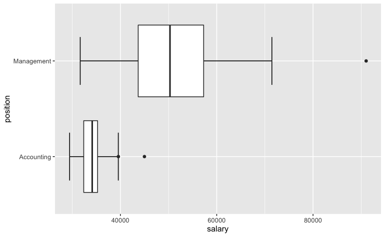

```r
jobs %>%
  ggplot() +
  aes(x = salary, y = position) +
  stat_boxplot(geom = "errorbar", width = 0.5) +
  geom_boxplot()
```

```r
NA
NA
```

whiskers are typically positioned 1.5 IQRs above and below Q1 and Q3 respectively. any points that lie outside of these are typically defined as outliers.

## Skew in boxplots

What does skew look like in a box plot?

```r
heavily_rskewed <- read_csv("heavily_right_skewed.csv")
```

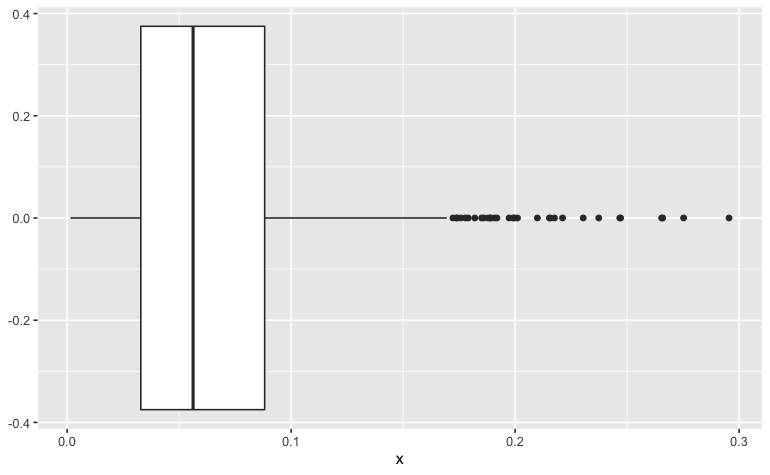

```r
heavily_rskewed %>%
  ggplot() +
  geom_boxplot(aes(x = x))
```

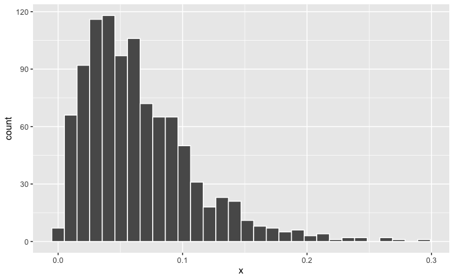

```r
heavily_rskewed %>%
  ggplot() +
  geom_histogram(aes(x = x), colour = "white", bins = 30)
```

task

```r
jobs %>%
  group_by(position) %>%
  summarise(skewness = skewness(salary, type = 1))
```

| position | skewness |
| --- | --- |
| Accounting | 0.9669488 |
| Management | 0.9146926 |

```r
NA
NA
```

- aside removing outliers from the data (potentially dangerous)
- get where Q1 and Q3 are
- get IQ range
- calculate distance to the whisker(1.5*IQR)
- filter values above Q3 + 1.5IQR and below Q1 - 1.5IQR

## Variance

- a single measure of spread how far each value is from the mean

How to calculate variance step by step 1. get the difference between each value and mean squared 2. sum them 3. divide by the total number of values - 1

In R - use the var function

```r
jobs %>%
  group_by(position) %>%
  summarise(variance = var(salary))
```

| position | variance |
| --- | --- |
| Accounting | 5681909 |
| Management | 119695746 |

this is dollars squared, which doesn’t really mean a lot to me

## Standard Deviation

- a more interpretable single measure spread of the data

to go from variance to SD, all we do is take the srqt

```r
jobs %>%
  group_by(position) %>%
  summarise(st_dev = sqrt(var(salary)),
            sd = sd(salary))
```

| position | st_dev | sd |
| --- | --- | --- |
| Accounting | 2383.676 | 2383.676 |
| Management | 10940.555 | 10940.555 |

```r
NA
```

so… if you come and work for TyrellCorp in Account, you can expect to earn 34,115 +/- 2,400 In management, you can expect to earn 51000 +/- 11,000

# Common distributions

## discrete vscontinuous variables

- all categorical variables are discrete (e.g strings)
- numerical variables can be discrete or continuous
- discrete are:
- continuous are:

Probability mass function For discrete variables: - bars / each prob must add up to 1 together - each bar individually must not be over 1

For continuous variables: - probability density; considering an area of the line/area, and then a subset of that

??

## Discrete uniform distribution

- there is equal probability for each outcome

## Cumulative distribution function

```r
dice <- tibble(
    x = 1:6,
    f_x = replicate(6, 1/6)
  ) %>%
  mutate(F_x = cumsum(f_x))

dice %>%
  ggplot(aes(x = x, y = F_x)) +
  geom_step() +
  xlab("number rolled on die") + ylab("probability") +
  scale_x_continuous(breaks = 1:6) +
  scale_y_continuous(breaks = seq(0, 1, 0.1)) +
  ylim(0, 1)
```

## Continuous distribution

something about cumulative density? - return to notes, something about functions in r? d(something) etc

## Normal distribution

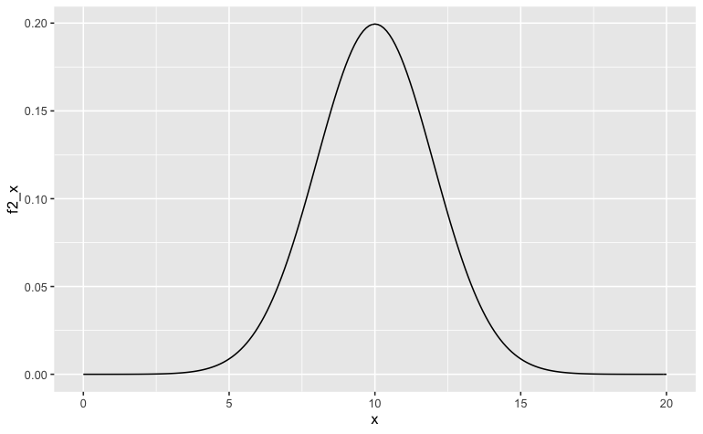

```r
three_norms <- tibble(
  x =  seq(0, 20, 0.1),
  f1_x = dnorm(x = x, mean = 10, sd = 1),
  f2_x = dnorm(x = x, mean = 10, sd = 2),
  f3_x = dnorm(x = x, mean = 10, sd = 3)
)
three_norms %>%
  ggplot() +
  geom_line(aes(x = x, y = f2_x), col = "black")
```

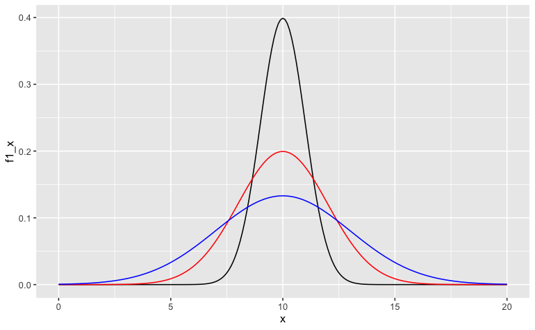

```r
three_norms %>%
  ggplot() +
  geom_line(aes(x = x, y = f1_x), col = "black") +
  geom_line(aes(x = x, y = f2_x), col = "red") +
  geom_line(aes(x = x, y = f3_x), col = "blue")
```

Although the tails do not hit 0, they do not reach 0 (the probability of getting that value becomes increasingly small)

## ” p ”

- qbinom and CDF are opposite functions / correspond to each other

## Standard normal, aka a z transform / z distribution

## Standard normal distribution

- has the mean set to 0 (standardised), and has the SD set to 1